# Econ 372 Homework 1: Adverse Selection in Real Markets

Author

Solutions

## Setup

```r
library(tidyverse)
library(scales)
library(knitr)
```

## Question 1: New Jersey’s individual market, 2000 to 2008

### (a) Build the dataset

The dataset comes from the New Jersey Department of Banking and Insurance Individual Health Coverage (IHC) data. For each year from 2000 to 2008, it has the monthly family premium for Horizon Blue Cross Blue Shield Plan D ($1,000 deductible), Aetna Plan D ($1,000 deductible), and Celtic Plan C ($2,500 deductible), along with total year-end standard enrollment in the IHC program. The file is `nj-ihc.csv` at the top of this repository, outside the gitignored `data/` folder so that it is included in the submission.

```r
nj <- read_csv("../nj-ihc.csv")

kable(nj, format.args = list(big.mark = ","),
      col.names = c("Year", "BCBS Plan D", "Aetna Plan D", "Celtic Plan C",
                    "Enrollment"),
      caption = "Monthly family premiums ($) and year-end standard enrollment, NJ IHC")
```

Monthly family premiums ($) and year-end standard enrollment, NJ IHC

| Year | BCBS Plan D | Aetna Plan D | Celtic Plan C | Enrollment |
| --- | --- | --- | --- | --- |
| 2,000 | 1,676.90 | 2,949 | 2,551 | 98,769 |
| 2,001 | 2,072.39 | 4,312 | 3,188 | 84,968 |
| 2,002 | 2,765.07 | 4,266 | 4,003 | 78,698 |
| 2,003 | 3,573.71 | 4,266 | 7,843 | 75,829 |
| 2,004 | 4,437.96 | 4,390 | 7,843 | 75,047 |
| 2,005 | 5,006.02 | 4,390 | 7,843 | 69,197 |
| 2,006 | 5,693.25 | 5,427 | 7,843 | 63,634 |
| 2,007 | 6,547.24 | 6,089 | 7,843 | 60,522 |
| 2,008 | 7,529.33 | 6,954 | 7,843 | 54,205 |

### (b) Make the figure

Premiums and enrollment are in different units, so the figure shows them in two panels over the same years.

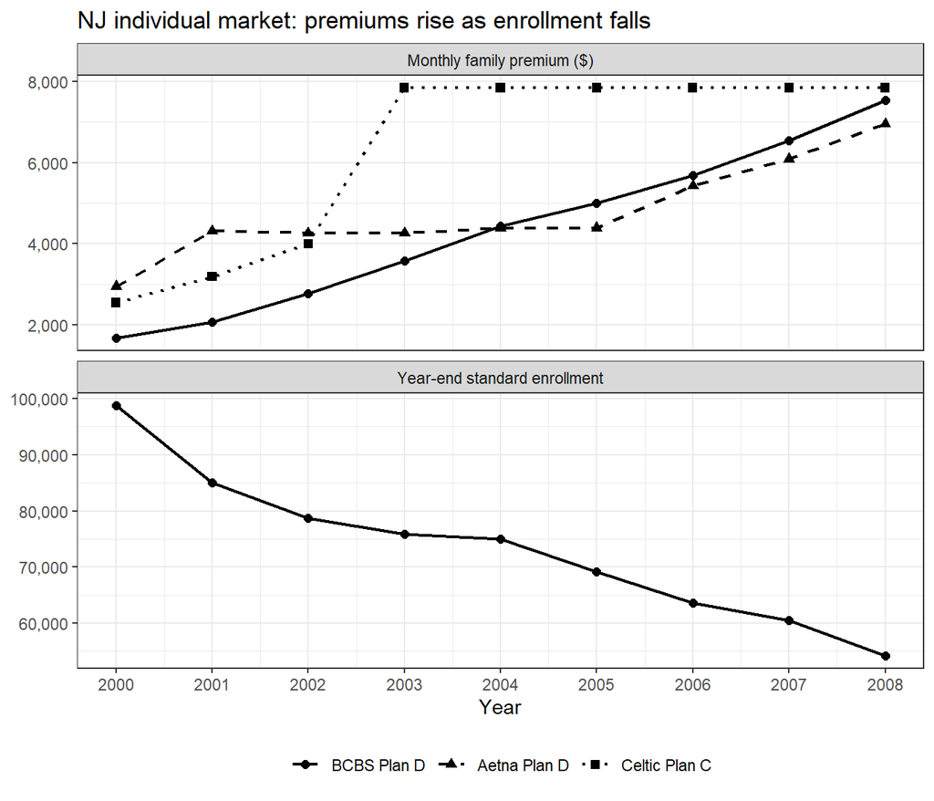

```r
nj_long <- bind_rows(
  nj %>%
    pivot_longer(c(bcbs_plan_d, aetna_plan_d, celtic_plan_c),
                 names_to = "series", values_to = "value") %>%
    mutate(panel = "Monthly family premium ($)",
           series = case_match(series,
                               "bcbs_plan_d" ~ "BCBS Plan D",
                               "aetna_plan_d" ~ "Aetna Plan D",
                               "celtic_plan_c" ~ "Celtic Plan C")),
  nj %>%
    transmute(year, series = "Enrollment", value = enrollment,
              panel = "Year-end standard enrollment")
)

ggplot(nj_long, aes(year, value, linetype = series, shape = series)) +
  geom_line(linewidth = 0.8) +
  geom_point(size = 2) +
  facet_wrap(~panel, ncol = 1, scales = "free_y") +
  scale_linetype_manual(values = c("BCBS Plan D" = "solid", "Aetna Plan D" = "dashed",
                                   "Celtic Plan C" = "dotted", "Enrollment" = "solid"),
                        breaks = c("BCBS Plan D", "Aetna Plan D", "Celtic Plan C")) +
  scale_shape_manual(values = c("BCBS Plan D" = 16, "Aetna Plan D" = 17,
                                "Celtic Plan C" = 15, "Enrollment" = 16),
                     breaks = c("BCBS Plan D", "Aetna Plan D", "Celtic Plan C")) +
  scale_x_continuous(breaks = 2000:2008) +
  scale_y_continuous(labels = comma) +
  labs(x = "Year", y = NULL, linetype = NULL, shape = NULL,
       title = "NJ individual market: premiums rise as enrollment falls") +
  theme_bw() +
  theme(legend.position = "bottom")
```

All three premiums rise sharply over the period. The BCBS Plan D premium goes from $1,677 a month in 2000 to $7,529 in 2008, about 4.5 times as high. Aetna rises from $2,949 to $6,954, and Celtic from $2,551 to $7,843, with Celtic’s premium nearly doubling in 2003 and unchanged after that. Enrollment drops sharply at first, from 98,769 in 2000 to 78,698 in 2002, and then levels off, at 75,047 in 2004, before declining more gradually to 54,205 in 2008.

### (c) Interpret it

Rising premiums together with falling enrollment is what adverse selection predicts. The IHC program was guaranteed issue and community rated, so insurers had to accept every applicant and charge everyone in a plan the same premium. When premiums rise, the people most likely to drop coverage are the healthiest, who expect to use the least care and so get the least value from insurance. Their exit leaves a sicker and more expensive pool, which raises the insurer’s average cost and leads to another premium increase the next year.

## Question 2: Medicare Advantage and fee-for-service, 2008 to 2023

### (a) Build the national series

```r
pen <- read_csv("../data/medicare-ma-penetration.csv", col_types = cols(fips = "c"))
ffs <- read_csv("../data/medicare-ffs-costs.csv", col_types = cols(fips = "c"))
```

Both files have one row per county and year, identified by the county FIPS code. The penetration file has 49,820 rows and the FFS file has 49,820. A few rows have missing values. There are 674 county-years with no reported MA enrollment, which I treat as zero, and 95 with missing FFS enrollment or spending, which I drop.

```r
pen <- pen %>% mutate(ma_enrolled = replace_na(ma_enrolled, 0))
ffs <- ffs %>% filter(!is.na(ffs_enrollment), !is.na(ffs_spending))

county <- pen %>%
  select(fips, year, total_eligibles, ma_enrolled) %>%
  inner_join(ffs %>% select(fips, year, ffs_enrollment, ffs_spending),
             by = c("fips", "year"), relationship = "one-to-one")
```

The merged file has 49,725 county-years, compared with 49,725 FFS rows after dropping the missing values, so every remaining FFS county-year finds a match in the penetration file. A national rate is not the average of the county rates, because that would give a small rural county the same weight as Los Angeles. Instead, I add up the counts across counties in each year and then divide. National MA penetration is total MA enrollment over total eligibles, and FFS spending per enrollee is total FFS spending over total FFS enrollment. Spending is converted to numeric before summing, since national FFS spending runs to hundreds of billions of dollars, beyond the largest integer R can store.

```r
national <- county %>%
  group_by(year) %>%
  summarize(ma_penetration = sum(ma_enrolled) / sum(total_eligibles),
            ffs_per_enrollee = sum(as.numeric(ffs_spending)) / sum(ffs_enrollment))

kable(national %>%
        mutate(ma_penetration = percent(ma_penetration, accuracy = 0.1),
               ffs_per_enrollee = dollar(ffs_per_enrollee, accuracy = 1)),
      col.names = c("Year", "MA penetration", "FFS spending per enrollee"),
      caption = "National MA penetration and FFS spending per enrollee")
```

National MA penetration and FFS spending per enrollee

| Year | MA penetration | FFS spending per enrollee |
| --- | --- | --- |
| 2008 | 22.0% | $8,481 |
| 2009 | 23.6% | $8,376 |
| 2010 | 24.4% | $8,522 |
| 2011 | 25.0% | $8,638 |
| 2012 | 26.5% | $8,486 |
| 2013 | 28.0% | $8,350 |
| 2014 | 29.9% | $8,370 |
| 2015 | 31.4% | $8,586 |
| 2016 | 32.0% | $8,617 |
| 2017 | 33.4% | $8,775 |
| 2018 | 34.1% | $9,027 |
| 2019 | 37.4% | $9,342 |
| 2020 | 39.9% | $8,954 |
| 2021 | 43.1% | $10,020 |
| 2022 | 46.0% | $10,230 |
| 2023 | 48.5% | $10,767 |

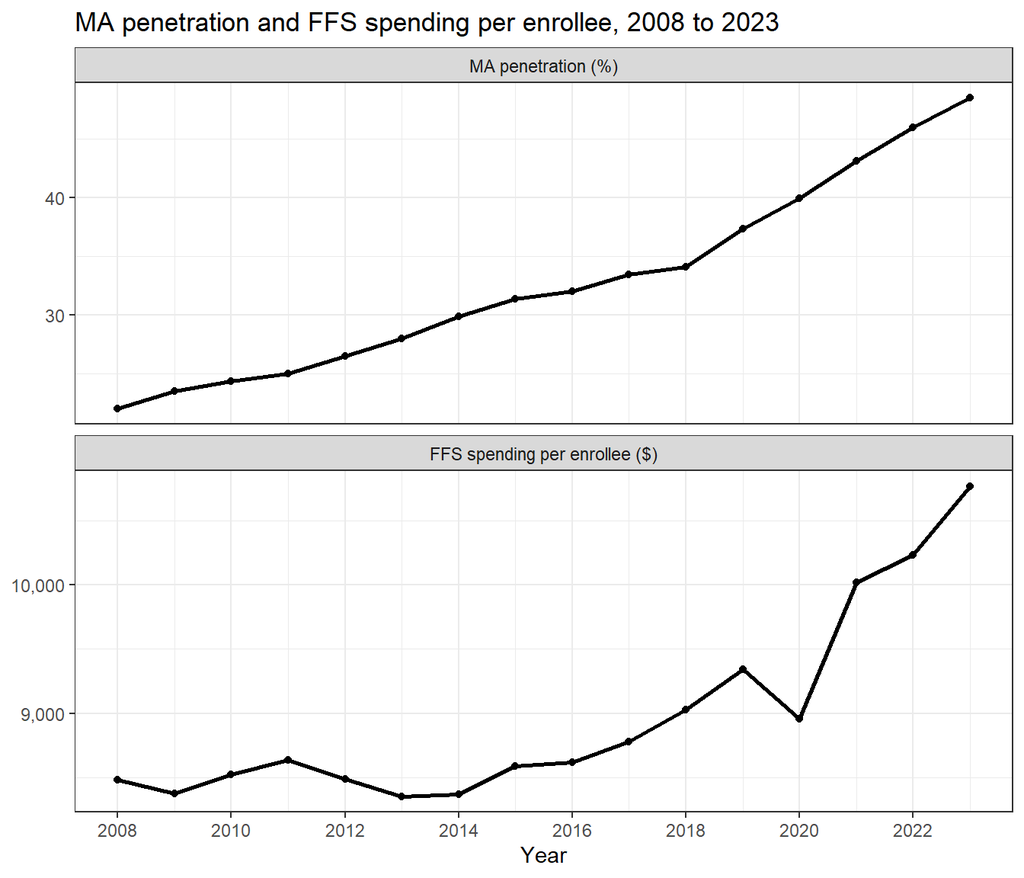

```r
national %>%
  transmute(year,
            `MA penetration (%)` = 100 * ma_penetration,
            `FFS spending per enrollee ($)` = ffs_per_enrollee) %>%
  pivot_longer(-year, names_to = "series", values_to = "value") %>%
  mutate(series = factor(series, levels = c("MA penetration (%)",
                                            "FFS spending per enrollee ($)"))) %>%
  ggplot(aes(year, value)) +
  geom_line(linewidth = 1) +
  geom_point() +
  facet_wrap(~series, ncol = 1, scales = "free_y") +
  scale_x_continuous(breaks = seq(2008, 2023, 2)) +
  scale_y_continuous(labels = comma) +
  labs(x = "Year", y = NULL,
       title = "MA penetration and FFS spending per enrollee, 2008 to 2023") +
  theme_bw()
```

MA penetration rises every year, from 22.0% of eligibles in 2008 to 48.5% in 2023, and it rises faster after 2018. FFS spending per enrollee, in nominal dollars, is nearly flat from 2008 to 2016, at $8,481 and $8,617. It then rises to $10,767 by 2023, with a dip in 2020, consistent with the disruption of care during the COVID pandemic, and a jump in 2021.

### (b) Read them together

The two series are consistent with healthier, lower-cost beneficiaries moving into Medicare Advantage and sicker, higher-cost beneficiaries staying in fee-for-service. As healthier people leave traditional Medicare, the people who remain are more expensive on average, which pushes up FFS spending per enrollee. This is adverse selection between two kinds of coverage, whereas in the model from class people choose whether to insure at all. The national series cannot establish selection on its own, however. FFS spending per enrollee also moves with medical prices and use, and it was nearly flat for most of the 2010s even as penetration kept rising, so the two series do not move together year by year.

### (c) Risk adjustment

Medicare pays an MA plan a fixed monthly amount for each enrollee. Risk adjustment scales that payment to the enrollee’s expected cost, using a risk score built from age, sex, and recorded diagnoses, so a plan is paid more for a sicker enrollee and less for a healthier one. The problem it addresses is the selection in part (b). With a flat payment per person, a plan would profit from attracting healthy enrollees and avoiding sick ones. Tying payment to expected cost reduces that reward, so plans have less reason to compete by choosing whom they enroll. Risk adjustment is imperfect, however. Because payment depends on recorded diagnoses, plans have an incentive to record diagnoses more completely, which can raise risk scores and payments without the enrollees being any sicker.

### (d) Beyond risk adjustment

One policy aimed at holding down fee-for-service costs is the Medicare Shared Savings Program, which pays accountable care organizations (ACOs). An ACO is a group of physicians, hospitals, and other providers that agrees to be held accountable for the total spending and quality of care of the traditional Medicare beneficiaries assigned to it. Providers are still paid fee-for-service, but if the ACO’s spending comes in below a benchmark and it meets quality standards, it keeps a share of the savings, and in some arrangements it owes Medicare part of any spending above the benchmark. That gives providers in traditional Medicare a reason to avoid unnecessary care, which they lack under fee-for-service alone ([MedPAC, “Accountable Care Organization Payment Systems,” Payment Basics, October 2024](https://www.medpac.gov/wp-content/uploads/2024/10/MedPAC_Payment_Basics_24_ACOs_FINAL_SEC.pdf)).